# Ejercicios de esperanza y varianza de variables aleatorias discretas

Marina Valdora

30 de abril de 2020

1. Se sabe que el 10% de los pacientes que presentan ciertos síntomas tiene una determinada enfermedad. El diagnóstico final de la misma depende de un análisis de sangre. Si embargo, como los análisis individuales son caros, el hemátologo espera hasta que N pacientes que presentan los sı́ntomas lo visiten. Entonces mezcla la sangre de los N pacientes y le hace el análisis. Si ninguna de las N personas esta enferma, entonces el análisis de la muestra es negativo. Sin embargo, si uno de los pacientes esta enfermo, entonces el análisis dará positivo y el hemátologo deberá hacer análisis individuales para determinar cuál de los pacientes está enfermo.
1. Encontrar la probabilidad de que el análisis sobre la sangre mezclada de positivo.
2. Si X = número de análisis que debe hacer el hemátologo sobre los N pacientes, determinar la función de probabilidad puntual de X.
3. Hallar la esperanza de X.
4. Graficar la probabilidad de que el análisis sobre la sangre mezclada de positivo y la esperanza de X en función de N.

Resolución del item d.

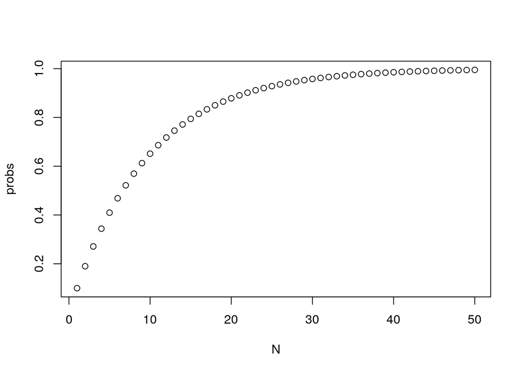

```r
N <- 1:50
probs <- 1-0.9^N
plot(N,probs)
```

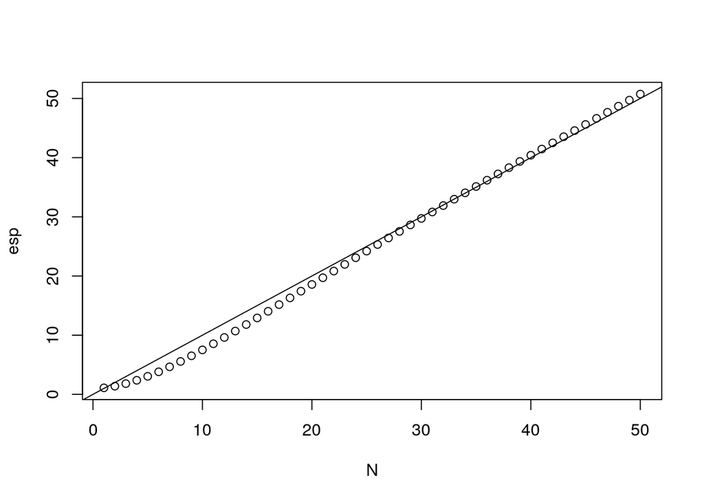

```r
esp <- 0.9^N+(N+1)*(1-0.9^N)
plot(N,esp)
abline(0,1)
```

2. Se disponen de dos urnas, rotuladas A y B. La primera contiene 5 bolitas azules y 6 rojas, y la otra tiene 1 bolita roja y 10 azules. Se saca una bolita de la primera urna, se la coloca en la urna B, se las mezcla y se extra otra de la segunda urna. Sea la variable aleatoria X = cantidad de bolitas rojas extraı́das.
1. Calcular la función de probabilidad puntual de X y su función de distribución acumulada.
2. Hallar E(X).
3. Estimar las probabilidades del item (a) y la esperanza del item (b) mediante una simulación.
4. Sea Y el número de bolitas azules extraı́das. Hallar la esperanza de Y.
5. Hallar la varianza de X y de Y.

Resolución del item c. Primero, defino una función que simula el experimento:

Simulación

```r
experimento<-function(){
  urna1 <- c(rep("a",5), rep("r",6))
  urna2 <- c(rep("a",10), rep("r",1))
  extraccion1 <- sample(urna1,1)
  urna2 <- c(extraccion1,urna2)
  extraccion2 <- sample(urna2,1)
  bolitas <- c(extraccion1,extraccion2)
  sum(bolitas=="r")
}
```

Segundo, repito 10000 el experimento y guardo los resultados en el vector {muchos_experimentos}

```r
muchos_experimentos <- replicate(10000, experimento())
```

Tercero, estimo las probabilidades como frecuencias relativas y las comparo con los valores obtenidos en (a)

```r
mean(muchos_experimentos==0)
```

```
## [1] 0.4212
```

```r
5/12
```

```
## [1] 0.4166667
```

```r
mean(muchos_experimentos==1)
```

```
## [1] 0.4893
```

```r
65/132
```

```
## [1] 0.4924242
```

```r
mean(muchos_experimentos==2)
```

```
## [1] 0.0895
```

```r
1/11
```

```
## [1] 0.09090909
```

Estimo la esperanza como el promedio de los valores observados

```r
mean(muchos_experimentos)
```

```
## [1] 0.6683
```